# Econometrics

## From $\hat p$ to $\hat Y_i(0)$: nearest neighbour, radius or kernel

Once every unit has its $\hat p$, we still have to decide **which controls** stand in for each treated unit, and with **which weights**: $\;\hat Y_i(0) = \sum_j w_{ij}\, Y_j$.

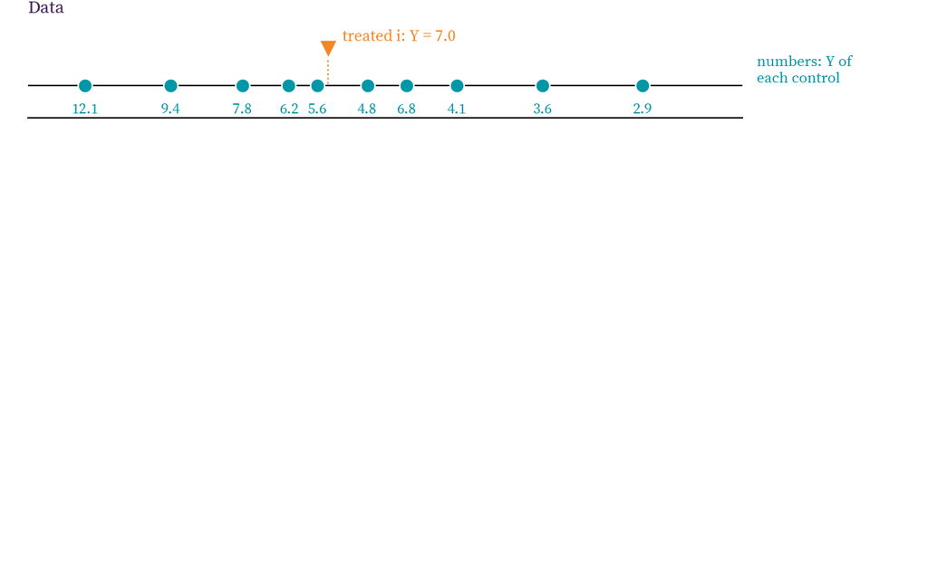

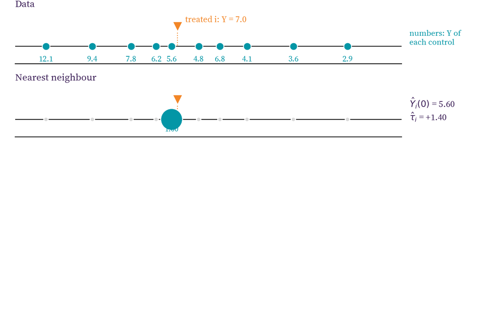

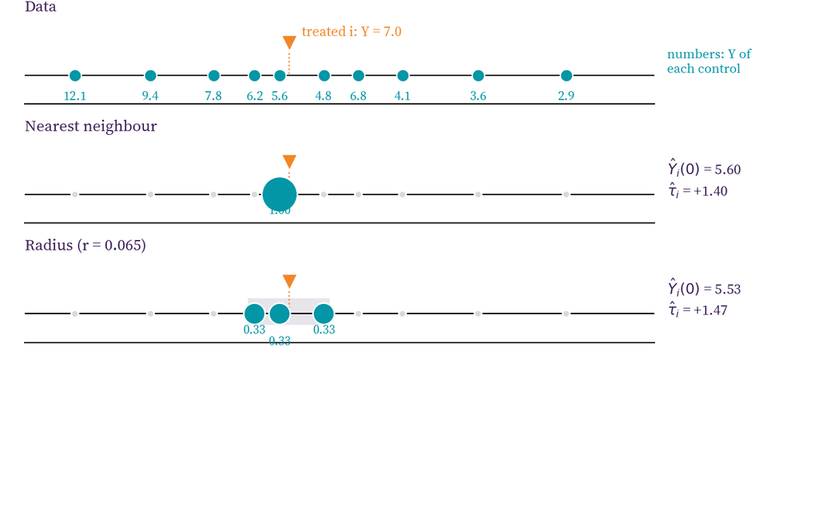

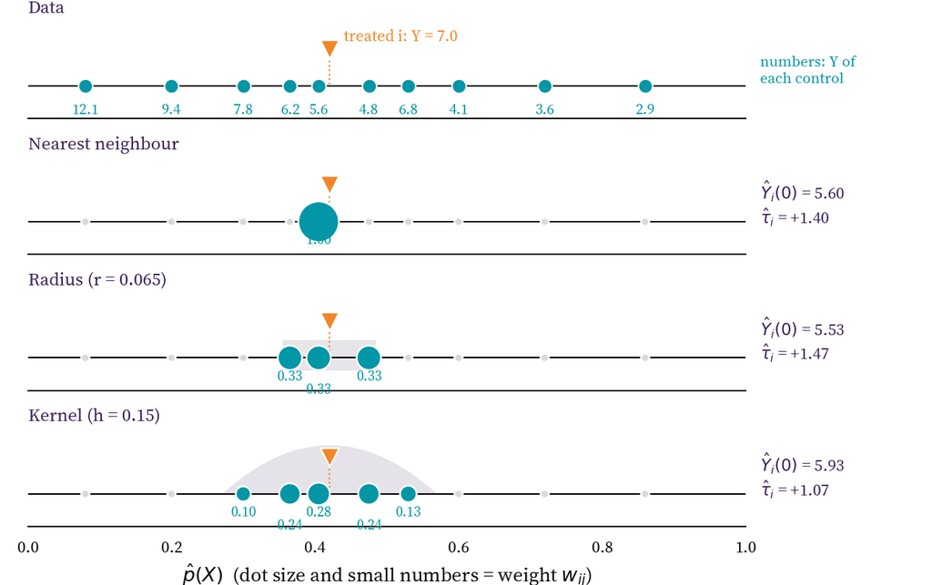

Three ways to build Ŷᵢ(0)

1. One treated unit \(i\) (▼, \(\hat p = 0.42\)) and ten controls, each with its \(\hat p\) and its \(Y\).
2. **Nearest neighbour**: only the closest control, weight 1 (with k neighbours, 1/k each). What we did so far.
3. **Radius**: every control within a distance r of \(\hat p_i\), equal weights. More controls, but you have to choose r.
4. **Kernel**: every control, weights falling with the distance (bandwidth h). Uses almost all the data → less variance; no analytical SE ⇒ **bootstrap**.

# 4 · Back to job training: which matching method wins?

## Common support in the NSW data

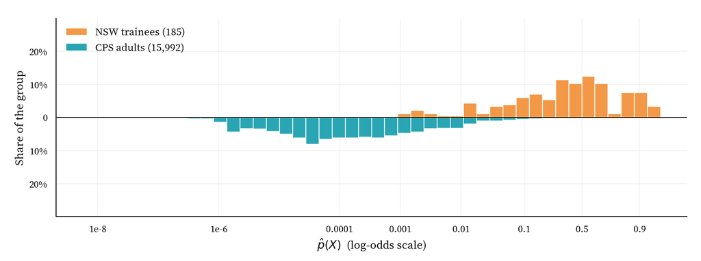

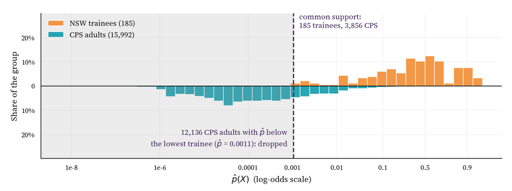

Most CPS adults have $\hat p \approx 0$: nobody like them enrolls in the program. They are **useless** as counterfactuals, and matching ignores them.

## Results: the effect of training with five matching methods

| Estimator | ATT (US$) | SE | Participants matched | Controls used | Mean \|bias\| (%) |
| --- | --- | --- | --- | --- | --- |
| Naive difference in means | -8,498 | (582) | 185 | 15,992 | 113.7 |
| OLS + X | 1,184 | (628) | 185 | 15,992 | – |
| NN on X (Mahalanobis) 🏆 | 2,035 | (948) | 185 | 118 | 2.1 |
| NN on p̂, k = 1 | 1,243 | (1,115) | 178 | 105 | 9.1 |
| NN on p̂, k = 5 | 1,859 | (884) | 178 | 361 | 3.4 |
| Radius (r = 0.01) | 1,625 | (975) | 166 | 3,850 | 3.9 |
| Kernel (bootstrap SE) | 1,740 | (840) | 178 | 3,856 | 4.6 |

## Which method balances the covariates best?

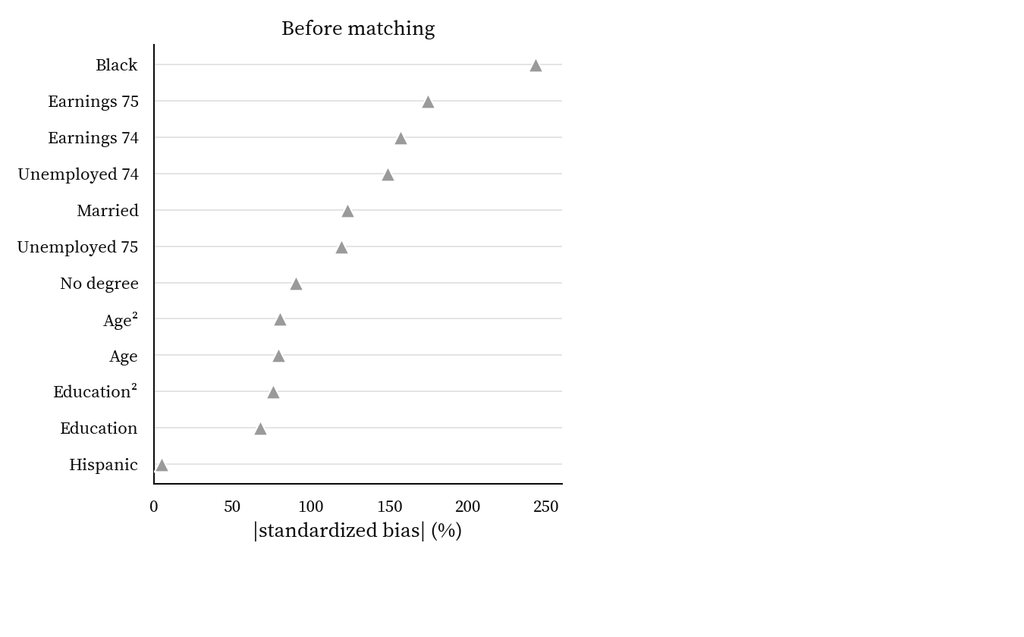

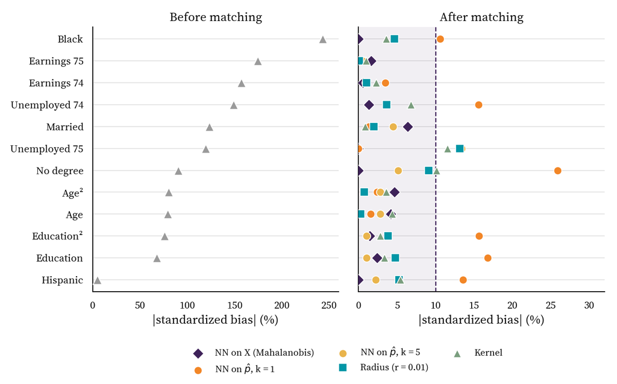

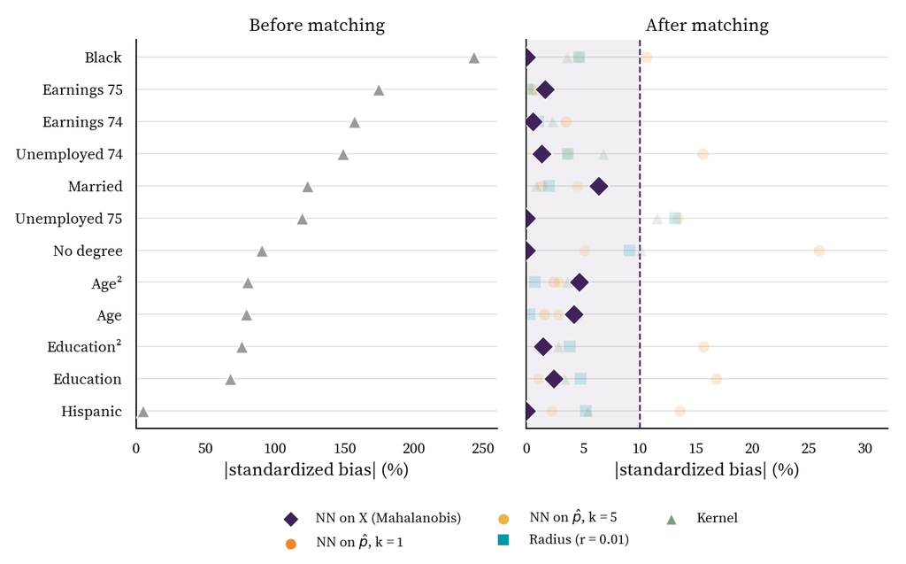

Love plot: balance by method

1. **Before matching**: participants and CPS adults differ by up to 243% of a standard deviation (mean 114%).
2. **After matching**, every method removes most of the imbalance (note the different scale).
3. 🏆 **NN on X (Mahalanobis)**: mean |bias| 2.1%, largest 6.4%. Worst: NN on p̂, k = 1 (9.1%).

Choose the method by **balance**, decided *before* looking at the ATT, never by the ATT you prefer. Here the winner gives **$2,035**.

## The propensity score before and after matching

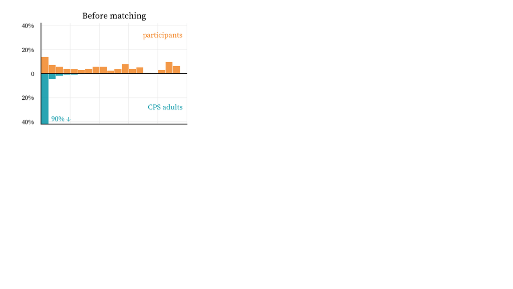

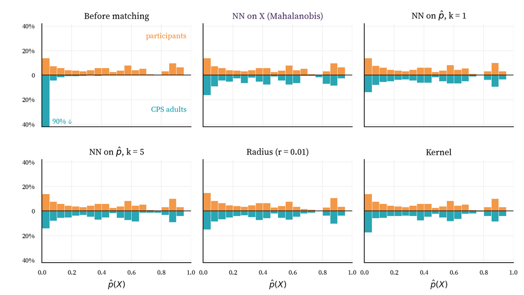

How to read it

1. **Before matching**: \(\hat p\) of the participants (up) and of the CPS adults on the common support (down). Almost all CPS adults sit at \(\hat p < 0.05\).
2. **After matching**: each CPS adult weighted by how much it is used. The matched CPS distribution now **mirrors** the participants': the groups are comparable in \(\hat p\).

Same check as the love plot, but for $\hat p$. Even matching on $X$ (Mahalanobis), which never uses $\hat p$, balances it. How: each CPS adult enters the histogram with its **matching weight** (how many times, or how much, it is used).

## Plot twist: the NSW was an experiment

The NSW participants were **randomly drawn** from the applicants; the 260 applicants randomized out form an **experimental control group**. So for this program we *know* the answer.

185

NSW participants

D = 1

260

NSW randomized controls

the experimental D = 0

15,992

CPS adults

a survey: non-experimental D = 0

| Comparison | Effect on 1978 earnings (US$) | SE |
| --- | --- | --- |
| **Experiment**: participants vs randomized controls | **1,794** | (671) |
| Naive: participants vs CPS adults | −8,498 | (582) |
| OLS + X: participants vs CPS adults | 1,184 | (628) |

**LaLonde (1986)** did exactly what we did today: throw away the experimental controls, use the CPS, and check whether non-experimental methods recover 1,794. Dehejia & Wahba (1999) showed that **matching** gets close.

## Did matching recover the experiment?

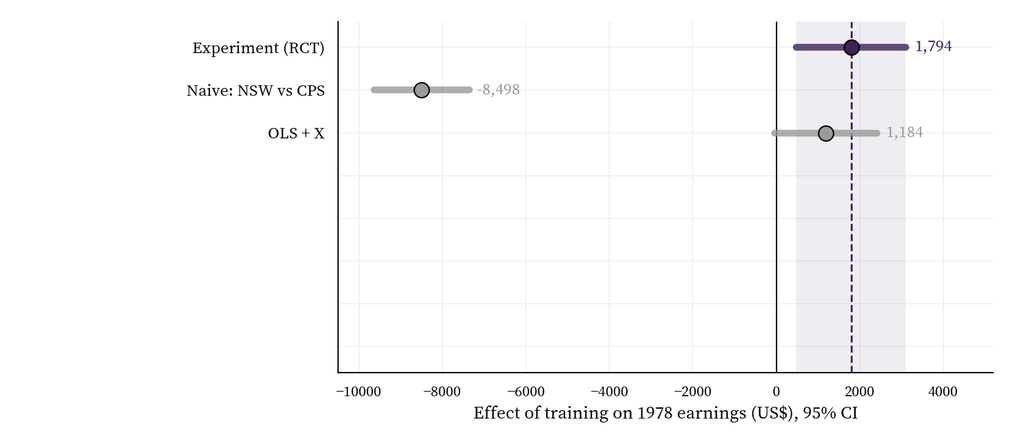

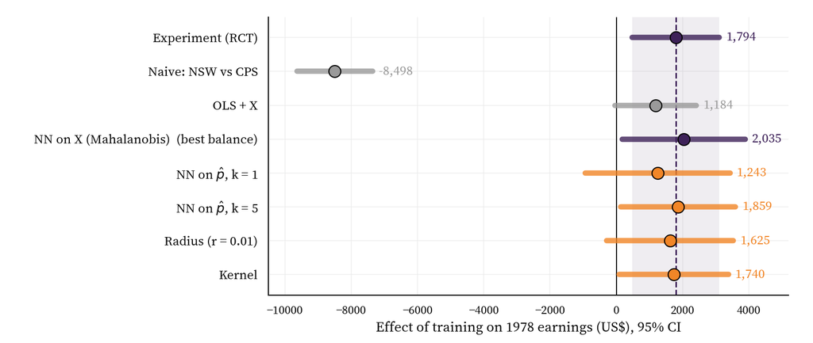

Once participants are compared with **comparable** CPS adults, every matching estimate lands inside the experimental 95% CI (shaded), the best-balanced one included. **But** we were lucky to observe the right $X$ (past earnings!): without them the CIA fails and no matching method can help (Smith & Todd, 2005).